# Topic 2: Programming in R

### What we will learn here

- Relational operators
- Logical operators
- Conditional statement
- Looping
- Function
- apply family: lapply, sapply, tapply

### ==

```r
2==2
```

```
## [1] TRUE
```

```r
2==3
```

```
## [1] FALSE
```

```r
TRUE==FALSE
```

```
## [1] FALSE
```

```r
TRUE==TRUE
```

```
## [1] TRUE
```

```r
2 != 3
```

```
## [1] TRUE
```

```r
"me" != "you"
```

```
## [1] TRUE
```

### < > <= >=

```r
2 > 5
```

```
## [1] FALSE
```

```r
2 < 5
```

```
## [1] TRUE
```

```r
2 >= 3
```

```
## [1] FALSE
```

```r
2 <= 3
```

```
## [1] TRUE
```

```r
3 <= 3
```

```
## [1] TRUE
```

### Relational operators on vector(s)

Suppose we have two vectors of average expenditure (in thousands) for 12 months in 2017 measured for 2 households: A and B. Now we are curious to know on which months the expenditure of A was above than a particular level and on which months A had more expenditure than B.

```r
average_exp_A = c(24, 28, 29, 31, 32, 32.5, 33, 33, 31, 30, 27, 22)
average_exp_B = c(25, 29, 30, 30, 31, 33, 34, 35, 30.9, 28, 25, 23)
# In which month, expenditur in A was lower than 30 K
average_exp_A < 30
```

```
##  [1]  TRUE  TRUE  TRUE FALSE FALSE FALSE FALSE FALSE FALSE FALSE  TRUE
## [12]  TRUE
```

```r
which(average_exp_A < 30)
```

```
## [1]  1  2  3 11 12
```

```r
#In which month A had more expenditure than B?
average_exp_A > average_exp_B
```

```
##  [1] FALSE FALSE FALSE  TRUE  TRUE FALSE FALSE FALSE  TRUE  TRUE  TRUE
## [12] FALSE
```

```r
which(average_exp_A > average_exp_B)
```

```
## [1]  4  5  9 10 11
```

We can also use this with matrices.

###Logical Operators

**AND** **&** **OR** **|** **NOT** **!**

**&&** and **||** only oerates on the first element of the two vectors we are comparing.

### if

if(a statement is true){ do something }

```r
profit = 200000
if(profit > 100000){
  print("Well done! Life is good")
}
```

```
## [1] "Well done! Life is good"
```

### else

```r
profit = 250000
if(profit > 500000){
  print("Great job!")
} else{
  print("Well done! But,we want more")
}
```

```
## [1] "Well done! But,we want more"
```

### else if

```r
if(profit < 200000){
  print("You need to do much more")
} else if(profit >=200000 & profit <=500000){
  print("Well done! But,we want more")
} else{
  print("Great job!")
}
```

```
## [1] "Well done! But,we want more"
```

### while loop

while(a condition is true) { continuously evaluate an expression }

#### Using while loop to sum up numbers between 1 and 100

```r
total = 0
num = 100
while(num>0){
  total = total + num
  num = num - 1
}
print(paste("The sum of numbers between 1 and 100 is ", total))
```

```
## [1] "The sum of numbers between 1 and 100 is  5050"
```

### break statement

```r
sum = 0
number = 5
while(number>0){
  if(number - 2 == 0){
    break
  }
  sum = sum + number
  number = number - 1
}
print(paste("The sum is now ", sum))
```

```
## [1] "The sum is now  12"
```

### for loop

for(variables in a sequence) { execute some expressions }

```r
val = c(20,35,111,22,34,47,89, 96)
for(value in val){
  print(value)
}
```

```
## [1] 20
## [1] 35
## [1] 111
## [1] 22
## [1] 34
## [1] 47
## [1] 89
## [1] 96
```

We can also use for loop with list, dataframe and matrix. We can use **break** statement with **for** loop.

### next statement

Using this statement, we can skip an iteration of a loop when a certain condition is met.

Suppose we want to print all the odd numbers in the vector **values**.

```r
numbers = c(22,77,90,86,37,113,25, 67,78,90,12,1)
for(value in numbers){
  if(value %% 2 == 0){
    next
  }
  print(value)
}
```

```
## [1] 77
## [1] 37
## [1] 113
## [1] 25
## [1] 67
## [1] 1
```

#### A different way to use for loop

```r
numbers = c(22,77,90,86,37,113,25, 67,78,90,12,1)
for(i in 1:length(numbers)){
  print(paste("Value number ",i, "is", numbers[i]))
}
```

```
## [1] "Value number  1 is 22"
## [1] "Value number  2 is 77"
## [1] "Value number  3 is 90"
## [1] "Value number  4 is 86"
## [1] "Value number  5 is 37"
## [1] "Value number  6 is 113"
## [1] "Value number  7 is 25"
## [1] "Value number  8 is 67"
## [1] "Value number  9 is 78"
## [1] "Value number  10 is 90"
## [1] "Value number  11 is 12"
## [1] "Value number  12 is 1"
```

### Functions

#### You provide input and output is calculated

Function allows to automate our code by matching input with provided arguments.

R does argument matching by both position and by name

```r
numbers = c(22,77,90,86,37,113,25, 67,78,90,12,1)
?hist
```

```
## starting httpd help server ... done
```

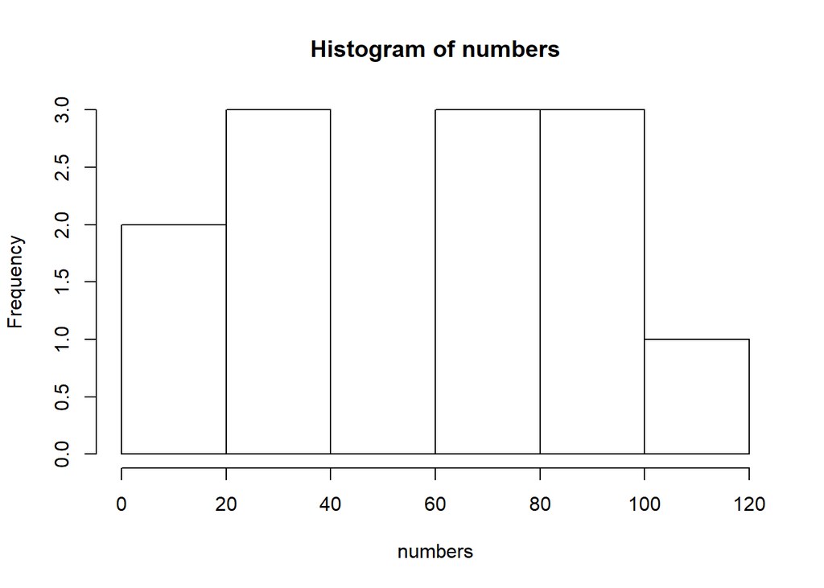

```r
hist(numbers)
hist(x=numbers)
```

We can find out all the arguments of a function by using **args()** function

```r
args(hist)
```

```
## function (x, ...)
## NULL
```

#### Optional argument– we provide the default value of the argument

```r
power_function = function(x, power = 2){
  x^power
}
power_function(2, 3)
```

```
## [1] 8
```

```r
power_function(2)
```

```
## [1] 4
```

### apply family: apply, sapply, tapply

```r
information = list(name = c("Aailiya", "Aayan", "Nibir", "Raffian"),
              age = c(4, 4, 5, 4),
              sex = c("Female", "Male", "Male", "Female"))
```

Let’s check the class of each list element

```r
for(element in information) {
  print(class(element))
}
```

```
## [1] "character"
## [1] "numeric"
## [1] "character"
```

### lapply()

**lapply()** applies function to each element of a list or vector and returns a list

```r
lapply(information, class)
```

```
## $name
## [1] "character"
##
## $age
## [1] "numeric"
##
## $sex
## [1] "character"
```

To return this as a vector, wrap the previous call inside **unlist()** in the following way:

```r
unlist(lapply(information, class))
```

```
##        name         age         sex
## "character"   "numeric" "character"
```

### Dollar to taka

```r
dollar = list(5643, 6456, 8542, 1343, 5439)
convert = function(x){
  x * 78
}
bd_taka = lapply(dollar, convert)
unlist(bd_taka)
```

```
## [1] 440154 503568 666276 104754 424242
```

### tapply

Very useful for summarizing data by group or category.

```r
# example taken from https://www.r-bloggers.com/r-function-of-the-day-tapply-2/
medical.example =
    data.frame(patient = 1:100,
               age = rnorm(100, mean = 60, sd = 12),
               treatment = gl(2, 50,
                 labels = c("Treatment", "Control")))

summary(medical.example)
```

```
##     patient            age            treatment
##  Min.   :  1.00   Min.   :24.92   Treatment:50
##  1st Qu.: 25.75   1st Qu.:49.82   Control  :50
##  Median : 50.50   Median :58.95
##  Mean   : 50.50   Mean   :59.07
##  3rd Qu.: 75.25   3rd Qu.:68.65
##  Max.   :100.00   Max.   :84.65
```

```r
# Get average age of treatment and control group
tapply(medical.example$age, medical.example$treatment, mean)
```

```
## Treatment   Control
##  59.04159  59.09808
```

### Anonymous function

```r
arrival_time = c("5:53:26", "12:51:21", "11:29:53", "1:48:41")
time = strsplit(arrival_time, split = ":")
#Select hour
unlist(lapply(time, function(x) {x[[1]]}))
```

```
## [1] "5"  "12" "11" "1"
```

### sapply()

**sapply** stands for simplify apply and is used with list or vector which tries to convert list to array

```r
books = c("Intro to Data Science", "Environment and Earth Observation", "Introduction to Remote Sensing", "Options, Futures and Other Derivatives", "Python Algorithms")
sapply(books, nchar)
```

```
##                  Intro to Data Science
##                                     21
##      Environment and Earth Observation
##                                     33
##         Introduction to Remote Sensing
##                                     30
## Options, Futures and Other Derivatives
##                                     38
##                      Python Algorithms
##                                     17
```

```r
#returns a one dimensional array
sapply(books, nchar, USE.NAMES = FALSE)
```

```
## [1] 21 33 30 38 17
```

### Returning multiple values in a function

#### calculating the highest digit in a number and the sum of digits of a number

```r
dollar = list(5643, 6456, 8542, 1343, 5439)
sum_largest = function(number) {
  numbers = as.numeric(unlist(strsplit(as.character(number), split="")))
  c(sum = sum(numbers), largest = max(numbers))
}

sum_largest(4500)
```

```
##     sum largest
##       9       5
```

```r
sapply(dollar, sum_largest)
```

```
##         [,1] [,2] [,3] [,4] [,5]
## sum       18   21   19   11   21
## largest    6    6    8    4    9
```

If the vectors to be returned are not of the same length, sapply returns a list.

### seq() append() rev()

```r
dat1 = seq(12, 50, 2)
dat1
```

```
##  [1] 12 14 16 18 20 22 24 26 28 30 32 34 36 38 40 42 44 46 48 50
```

```r
dat2 = seq(50,12,-2)
dat2
```

```
##  [1] 50 48 46 44 42 40 38 36 34 32 30 28 26 24 22 20 18 16 14 12
```

```r
dat7 = append(dat1, dat2)
dat7
```

```
##  [1] 12 14 16 18 20 22 24 26 28 30 32 34 36 38 40 42 44 46 48 50 50 48 46
## [24] 44 42 40 38 36 34 32 30 28 26 24 22 20 18 16 14 12
```

### Regular Expressions

#### grepl()

**grepl()** returns TRUE when a pattern is matched in a character string

```r
items = c("Pen", "Pencil", "Book", "Phone","Cycle")
```

**grepl(pattern = pattern, x = string)**

```r
grepl(pattern = "cy", x = items)
```

```
## [1] FALSE FALSE FALSE FALSE FALSE
```

### Times and Dates

```r
Sys.Date()
```

```
## [1] "2018-09-23"
```

```r
class(Sys.Date())
```

```
## [1] "Date"
```

```r
Sys.time()
```

```
## [1] "2018-09-23 07:34:01 +06"
```

```r
class(Sys.time())
```

```
## [1] "POSIXct" "POSIXt"
```

#### reading Date Object

```r
arbDay = as.Date("2023-11-13")
class(arbDay)
```

```
## [1] "Date"
```

```r
#The below line will throw an error
#birthday = as.Date("1985-27-07")
arbday2 = as.Date("1995-14-03", format = "%Y-%d-%m")
class(arbday2)
```

```
## [1] "Date"
```

### POSIXct object

```r
result_day = as.POSIXct("2005-04-17 14:27:14")
result_day
```

```
## [1] "2005-04-17 14:27:14 +06"
```

```r
result_day2 = as.POSIXct("2003-11-03 10:21:13", format="%Y-%m-%d %H:%M:%S")
result_day2
```

```
## [1] "2003-11-03 10:21:13 +06"
```

We can do arithmetic opearations on dates.

R stores dates as numeric number. This number is the number of days from January 1, 1970 for Date object or the number of seconds from the start of midnight of January 1, 1970 for POSIXct object.

```r
result_day - result_day2
```

```
## Time difference of 531.1708 days
```

### Scoping rules

R follows lexical scoping that is the values of free variables are looked up for in the environment in which the function is defined.

```r
power_function = function(a){
  power = function(x) {
    x^a
  }
  power
}
#power_function
square = power_function(2)
cube = power_function(3)
square(4)
```

```
## [1] 16
```

```r
cube(4)
```

```
## [1] 64
```

#### Profiling – performance analysis – how much time is it taking to run different parts of the program

**system.time()**